# Definisi Stack

Stacks adalah satu struktur data dimana penambahan dan penghapusan data, hanya dapat dilakukan pada satu ujung yang sama, atau yang biasa dikenal dengan istilah top. Semakin data jauh berada dari posisi top, maka data tersebut diindikasikan berada di stack lebih lama dibandingkan dengan data yang berada dekat pada data di posisi top. Jika terdapat data baru yang ditambahkan di stack, maka data ini pulalah yang akan dihapus ketika terdapat proses penghapusan data. Konsep ini dikenal dengan nama LIFO-Last In First Out.

```python
#cek kurung
def cek(s):
    stack = []
    for i in s:
        if i == '(':
            stack.append(i)
        elif i == ')':
            if not stack:
                return False
            stack.pop()
    return len(stack) == 0
```

```python
#menghitung genap
def hitungGenap(stack):
    count = 0
    for i in stack:
        if i % 2 == 0:
            count += 1
    return count
```

# Operasi pada Stacks

Terdapat operasi dasar pada Stacks,

- stack (), inisialisasi stack yang kosong
- push(data), penambahan data baru pada posisi top dari stack
- pop(), penghapusan data yang terdapat di posisi top dari stack. R eturn value dari fungsi ini adalah data yang dihapus dari stack tersebut
- peek(), informasi data yang terletak pada posisi top
- isEmpty(), untuk memeriksa apakah stack dalam keadaan kosong
- size(), informasi jumlah data yang terdapat pada stack

# PUSH

Push adalah penambahan data baru pada posisi top dari stack

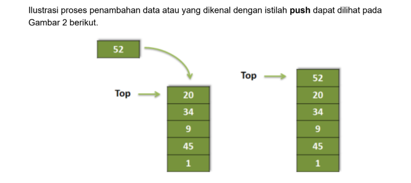

*Implementasi Stack Push:*

```python
stack = []
stack.append('I')
stack.append('R')
stack.append('M')
stack.append('A')
print("Push" , stack)
```

```
Push ['I', 'R', 'M', 'A']
```

# PEEK

Peek adalah informasi data yang terletak pada posisi top. Operasi untuk melihat elemen teratas pada stack tanpa menghapusnya.

*Implementasi Stack Peek*

```python
stack = []
stack.append('I')
stack.append('R')
stack.append('M')
stack.append('A')
topElement = stack[3]
print("Peek: ", topElement)
```

```
Peek:  A
```

# POP

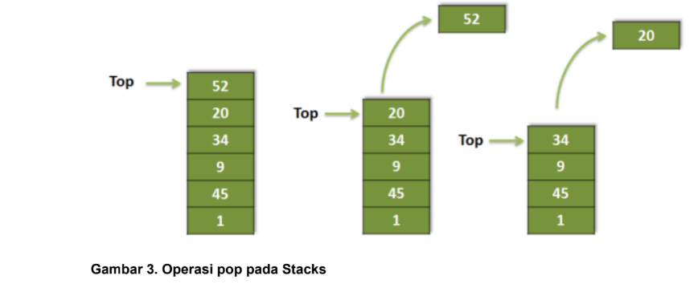

*Implementasi Stack Pop:*

```python
stack = []
stack.append('I')
stack.append('R')
stack.append('M')
stack.append('A')
poppedElement = stack.pop(2)
print("Pop: ", poppedElement)
print("Stack after Pop: ", stack)
```

```
Pop:  M
Stack after Pop:  ['I', 'R', 'A']
```

```python
#membalik kata
def balik(kata):
    stack = []
    for i in kata:
        stack.append(i)
    hasil = ""
    while stack:
        hasil += stack.pop()
    return hasil
```

# isEmpty

Operasi untuk memeriksa apakah stack dalam keadaan kosong atau tidak, jika dalam keadaan kosong maka akan bernilai True, namun jika ada isi maka bernilai False. *Implementasi isEmpty:*

```python
stack = []
isEmpty = not bool(stack)
print("isEmpty: ", isEmpty)
```

```
isEmpty:  True
```

# SIZE

Operasi informasi jumlah data yang terdapat pada stack

*Implementasi Stack Size:*

```python
stack = []
stack.append('I')
stack.append('R')
stack.append('M')
stack.append('A')
stack.append('A')
print("Size: ",len(stack))
```

```
Size:  5
```

# STACK MENGGGUNAKAN CLASS

Berikut Implementasi code nya:

```python
class Stack:
  def __init__(self):
    self.stack = []

  def push(self, element):
    self.stack.append(element)

  def pop(self):
    if self.isEmpty():
      return "Stack is empty"
    return self.stack.pop()

  def peek(self):
    if self.isEmpty():
      return "Stack is empty"
    return self.stack[-1]

  def isEmpty(self):
    return len(self.stack) == 0

  def size(self):
    return len(self.stack)


myStack = Stack()

myStack.push('B')


print("Stack: ", myStack.stack)
print("Pop: ", myStack.pop())
print("Stack after Pop: ", myStack.stack)
print("Peek: ", myStack.peek())
print("isEmpty: ", myStack.isEmpty())
print("Size: ", myStack.size())
```

```
Stack:  ['B']
Pop:  B
Stack after Pop:  []
Peek:  Stack is empty
isEmpty:  True
Size:  0
```

# STACK MENGGUNAKAN FUNCTION

Berikut merupakan Implementasi codenya :

```python
def stack():
    s = []
    return s

def push(s, data):
    s.append(data)

def pop(s):
    return s.pop()

def peek(s):
    return s[len(s)-1]

def isEmpty(s):
    return (s == [])

def size(s):
    return len(s)


s = stack()

push(s, 'I')
push(s, 'R')
push(s, 'M')

print("Stack:", s)
print("Peek:", peek(s))
print("Size:", size(s))
print("Pop:", pop(s))
print("Stack setelah pop:", s)
print("isEmpty:", isEmpty(s))
```

```
Stack: ['I', 'R', 'M']
Peek: M
Size: 3
Pop: M
Stack setelah pop: ['I', 'R']
isEmpty: False
```

# CONTOH SOAL

User meminta mengembalikan huruf yang berbentuk kata, berikut Implementasi codenya:

```python
data = ['T', 'U', 'M', 'I']
stack = []

for item in data:
    stack.append(item)

reversed_data = []
while stack:
    reversed_data.append(stack.pop())

print(reversed_data)
```

```
['I', 'M', 'U', 'T']
```

# CONTOH SOAL PILIHAN GANDA

1.Apa yang dimaksud dengan struktur data Stack? A. Struktur data dengan prinsip FIFO  
B. Struktur data dengan prinsip LIFO  
C. Struktur data berbentuk pohon  
D. Struktur data berbentuk graf  
**Jawaban :** B. Struktur Data dengan Prinsip LIFO

2.Operasi utama pada Stack adalah… A. Insert dan Delete  
B. Push dan Pop  
C. Enqueue dan Dequeue  
D. Search dan Sort  
**Jawaban :** B. Push dan Pop

3.Jika stack berisi:  
[10, 20, 30]  
Elemen terakhir yang dimasukkan adalah?  
**Jawaban :** 30

4.Jika dilakukan operasi pop() pada stack:  
[5, 8, 12, 20]  
Maka elemen yang keluar adalah?  
**Jawaban :** 20

5.Diketahui stack kosong. Lakukan:  
Push(A)  
Push(B)  
Push(C)  
Pop()  
Pop()  
Push(D)  
Tentukan isi stack akhir!  
**Jawaban :** (A,D)

6.Diketahui stack kosong. Lakukan operasi berikut:  
Push(10)  
Push(15)  
Push(20)  
Pop()  
Push(25)  
Tentukan isi stack akhir!  
**Jawaban :** (10,15,25)

7.Buatlah fungsi untuk mengecek apakah suatu string merupakan palindrome menggunakan stack.  
Input: "KATAK"  
Output: Palindrome  
**Jawaban :**

```python
class Stack:
    data = []

    def push(self, huruf):
        self.data.append(huruf)

    def pop(self):
        return self.data.pop()

    def size(self):
        return len(self.data)

kata_asli = "KATAK"
s = Stack()

for h in kata_asli:
    s.push(h)

kata_terbalik = ""
while s.size() > 0:
    kata_terbalik += s.pop()

print("Kata Asli:", kata_asli)
print("Kata Terbalik:", kata_terbalik)

if kata_asli == kata_terbalik:
    print("KESIMPULAN: Palindrome")
else:
    print("KESIMPULAN: Bukan Palindrome")
```

```
Kata Asli: KATAK
Kata Terbalik: KATAK
KESIMPULAN: Palindrome
```

# CONTOH SOAL

Membalik Urutan Kata dalam Kalimat. Berikut implementasi code nya:

```python
kalimat = input("Masukkan kalimat: ")
kata = kalimat.split()

stack = []

#push untuk menambah kata
for k in kata:
    stack.append(k)

#mengembalikan menggunakan kata
hasil = []
while stack:
    hasil.append(stack.pop())

print("Output:", hasil)
```

```
Output: ['canntik', 'sangat', 'irma']
```

# CONTOH SOAL

Menghitung Jumlah Elemen Tanpa len() Diketahui stack berisi:

[10, 20, 30, 40, 50]

Buat program untuk menghitung jumlah elemen tanpa menggunakan fungsi len().

```python
stack = [10, 20, 30, 40, 50]

count = 0
for _ in stack:
    count += 1

print("Jumlah elemen:", count)
```

```
Jumlah elemen: 5
```

# CONTOH SOAL

Menghapus Angka 30 Tanpa Merusak Urutan Diketahui stack:

[10, 20, 30, 40, 50]

Buat program untuk menghapus angka 30 tanpa merusak urutan elemen lainnya.

```python
stack = [10, 20, 30, 40, 50]
temp = []

# pindahkan elemen sampai ketemu 30
while stack:
    x = stack.pop()
    if x == 30:
        break
    temp.append(x)

# kembalikan elemen lain tanpa 30
while temp:
    stack.append(temp.pop())

print("Stack setelah hapus 30:", stack)
```

```
Stack setelah hapus 30: [10, 20, 40, 50]
```

# CONTOH SOAL

Parkiran maksimal 5 mobil.

Mobil masuk → push

Mobil keluar → pop

Jika penuh → tampilkan pesan

```python
parkiran = []
maksimal = 5

#jumlah data mobil yang masuk
parkiran.append("B 1234 AA")
parkiran.append("B 5678 BB")
parkiran.append("B 9999 CC")
parkiran.append("B 1111 DD")
parkiran.append("B 2222 EE")


if len(parkiran) >= maksimal:
    print("Parkiran Penuh!")
else:
    parkiran.append("B 3333 FF")

print("Isi parkiran:", parkiran)

# Mobil keluar (LIFO)
keluar = parkiran.pop()
print("Mobil keluar:", keluar)

print("Sisa parkiran:", parkiran)
```

```
Parkiran Penuh!
Isi parkiran: ['B 1234 AA', 'B 5678 BB', 'B 9999 CC', 'B 1111 DD', 'B 2222 EE']
Mobil keluar: B 2222 EE
Sisa parkiran: ['B 1234 AA', 'B 5678 BB', 'B 9999 CC', 'B 1111 DD']
```

# Definisi Queue

Pengertian

Queue (antrian) adalah struktur data di mana: data masuk dari belakang (rear) data keluar dari depan (front) Menggunakan prinsip FIFO (First In First Out), yaitu yang masuk dulu keluar dulu.

*Konsep Penting* Front: elemen pertama (yang akan keluar)

Rear: elemen terakhir (tempat masuk data baru)

FIFO: urutan berdasarkan waktu masuk

*Operasi pada Queue*

- enqueue(item) → menambah data ke belakang
- dequeue() → menghapus data dari depan
- isEmpty() → cek apakah kosong
- size() → jumlah data

*Contoh :*

Queue awal: []

enqueue(10) → [10]

enqueue(20) → [10, 20]

enqueue(30) → [10, 20, 30]

dequeue() → 10 keluar

hasil: [20, 30]

Berikut Implementasi Codenya:

```python
#menampilkan tanpa hapus
for i in queue:
    print(i)
```

```python
class Queue:
    def __init__(self):
        self.items = []

    def isEmpty(self):
        return self.items == []

    def enqueue(self, item):
        self.items.insert(0, item)

    def dequeue(self):
        return self.items.pop()

    def size(self):
        return len(self.items)


# Contoh penggunaan
q = Queue()
q.enqueue(10)
q.enqueue(20)
q.enqueue(30)

print("Queue:", q.items)
print("Dequeue:", q.dequeue())
print("Queue sekarang:", q.items)
```

```
Queue: [30, 20, 10]
Dequeue: 10
Queue sekarang: [30, 20]
```

# Definisi Deque (Double Ended Queue)

Pengertian Deque adalah struktur data yang mirip queue, tetapi bisa:

menambah data dari depan maupun belakang, menghapus data dari depan maupun belakang Jadi, deque lebih fleksibel dibanding queue.

*Konsep Penting*

- Memiliki dua sisi: front dan rear
- Tidak hanya FIFO, bisa berbagai pola tergantung penggunaan

*Operasi pada Deque*

- addFront(item) → tambah ke depan
- addRear(item) → tambah ke belakang
- removeFront() → hapus dari depan
- removeRear() → hapus dari belakang
- isEmpty() → cek kosong
- size() → jumlah data

*Contoh*

Deque awal: []

addFront(10) → [10]

addRear(20) → [20, 10]

addFront(30) → [20, 10, 30]

removeRear() → 20 keluar hasil: [10, 30]

Berikut Implementasi Codenya:

```python
class Deque:
    def __init__(self):
        self.items = []

    def isEmpty(self):
        return self.items == []

    def addFront(self, item):
        self.items.append(item)

    def addRear(self, item):
        self.items.insert(0, item)

    def removeFront(self):
        return self.items.pop()

    def removeRear(self):
        return self.items.pop(0)

    def size(self):
        return len(self.items)


# Contoh penggunaan
d = Deque()
d.addFront(10)
d.addRear(20)
d.addFront(30)

print("Deque:", d.items)
print("Remove rear:", d.removeRear())
print("Deque sekarang:", d.items)
```

```
Deque: [20, 10, 30]
Remove rear: 20
Deque sekarang: [10, 30]
```

```python
from collections import deque
d = deque()

d.append(x)        # addRear
d.appendleft(x)    # addFront
d.pop()            # removeRear
d.popleft()        # removeFront
```

```python
#cek palindrome
from collections import deque

def palindrome(kata):
    d = deque(kata)
    while len(d) > 1:
        if d.popleft() != d.pop():
            return False
    return True
```

```python
def cek_palindrome_stack(kata):
    stack = []

    # push ke stack
    for huruf in kata:
        stack.append(huruf)

    # pop dari stack untuk membalik
    hasil = ""
    while stack:
        hasil += stack.pop()

    # cek
    if hasil == kata:
        return "Palindrome"
    else:
        return "Bukan Palindrome"


# contoh
print(cek_palindrome_stack("katak"))
print(cek_palindrome_stack("halo"))
```

[output not shown]

# Table Perbedaan

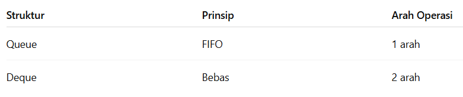